# NIST_1.2

Sakaguchi

2025-05-02

# EDA Assumptions

- **Summary**
- 科学的工学的実験の範囲は事実上無限
- 体系的かつ妥当性あり、裏付けと再現性のある研究結果を導出可能な基盤はあるのか?
- そのような基礎がある
  - 複雑な測定プロセスでもその根底には一定の前提ありという事実に根差す
  - このセクションで議論すること
    - そのような仮定は何か?
    - なぜ重要か?
    - どのように仮定を検定するのか?
    - 成立しない場合はどのような結果になるのか?
- **Section2のコンテンツ**
  1. 根底にある仮定
  2. 重要事項
  3. 検定における前提
  4. プロットの重要性
  5. 結果

## [1.2.1. Underlying Assumptions](https://www.itl.nist.gov/div898/handbook/eda/section2/eda21.htm)

- **測定プロセスに係る仮定**
- すべての測定プロセスで得られるデータのふるまいとして仮定されること
  1. 無作為抽出
  2. 固定の分布からなること
  3. 位置固定の分布を持つ
  4. 固定変動の分布を持つ
- **「位置固定」**の異なるタイプの問題
  - 最も単純な[単変数]タイプ
    - response = deterministic component + random component
    - becomes
      - response = constant + error
- **単変数モデルにおける仮定**
- このケースの「固定位置」は単純に未知の定数のこと
- 以下のような特性を持つデータを生成する一定の条件があると想定できる
  - あるデータは他のデータと相関はない
  - ランダムな成分は固定の分布を有する
  - 決定的成分は定数
  - ランダム成分は固定の変動
- **多変数系への拡張**
- 単変数モデルの普遍的な検定力、重要性
  - 決定論的要素が多変数関数であるより一般的なモデルに容易に拡張可能
- 残差のふるまい
  - 実際の応答と**フィットした**モデルによる予測値の差は単変数プロセスと同様のふるまい(重要)
  1. 無作為抽出
  2. 固定の分布からなること
  3. 位置固定の分布を持つ
  4. 固定変動の分布を持つ
- フィットしたモデルから得られる残差の挙動を検定
  - もし上記の条件が成立しない
    - 選択したモデルが不適で改良の必要あり

## [1.2.2. Importance](https://www.itl.nist.gov/div898/handbook/eda/section2/eda22.htm)

- **予測可能性と統計的管理**
- 予測可能性
  - 科学・エンジニアリングにおける重要な目標
  - 4つの仮定が成り立つなら、確率的予測可能性を達成と言える
    - 過去だけでなく未来のプロセスも見通せる
      - **統計的管理**
- **エンジニアリング上の結論における妥当性**
- 4つの仮定が当てはまる場合
  - プロセスは科学的・エンジニアリング的に妥当な結論を得る
- 4つの仮定が当てはまらない場合
  - プロセスはドリフト(位置、変動、分布等の)
  - 予測可能ではなく、**Out Of Control**
- 位置、変動、分布の推定のみで単純にプロセスの特徴づけ
  - 裏付け乏しく、実験再現不可能な工学的結論が導出されうる

## [1.2.3.Techniques for Testing Assumptions](https://www.itl.nist.gov/div898/handbook/eda/section2/eda23.htm)

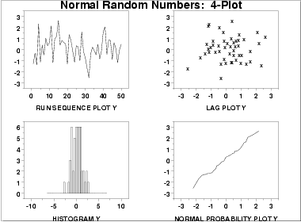

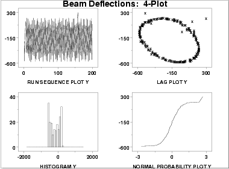

## [1.2.4. Interpretation of 4-Plot](https://www.itl.nist.gov/div898/handbook/eda/section2/eda24.htm)

- **EDAプロットの解釈**
- 4つのEDAプロット
  - 基礎となる仮定の検定に使用
    1. 固定位置(の検定)
    - ランシーケンスプロットはフラットでドリフトない
    2. 固定変動
    - ランシーケンスプロットの縦方向の広がり均等
    3. 無作為性
    - ラグプロットは特定の構造見られず無作為的
    4. 固定分布
       1. ヒストグラムはベル形状
       2. 正規確率プロットが直線状
- **プロットを仮定の検定に適用**
- ランシーケンスプロット
  - フラットでドリフトない場合、固定位置の仮定を維持
  - 垂直方向の広がりがほぼ同じ程度の場合、固定変動の仮定を維持
- ラグプロット
  - プロットに特定構造ない場合、無作為性の仮定維持
- ヒストグラム
  - ベル形状の場合、対称型の分布、おそらくは正規分布と想定
- 正規確率プロット
  - 直線状となる場合、分布はおよそ正規性と言える
- 4つの仮定がすべて維持されている場合
  - プロセスは定義上[**統計的管理**]にあると言える

## [1.2.5. Consequences](https://www.itl.nist.gov/div898/handbook/eda/section2/eda25.htm)

- **仮定が成立しない場合**
- 基礎となる仮定不成立の場合に出来ることは?
  - 是正措置、積極的に対応する方法は?
    - 仮定の検定を、プロセス理解の為の枠組みとすること
    - 表面化しなかったかもしれないプロセスの重要な側面に対する洞察
- **最初の目標: 正しく妥当な科学的結論**
- 通常、中間の目標を有する
  - よくフィットしたモデル
  - 現実的なパラメータ推定
- 常に「何がプロセスを動かしているか」を理解し「感じる」とう目標を含む
- 続く章で以下を議論
  1. 非ランダムの結果
  2. 位置パラメータ固定でない場合
  3. 変動固定でない場合
  4. 分布に関する仮定関連の結論

## [1.2.5.1. Consequences of Non-Randomness](https://www.itl.nist.gov/div898/handbook/eda/section2/eda251.htm)

- **無作為性という仮定**
- 何度も言いますが以下
  1. 無作為抽出
  2. 固定の分布からなること
  3. 位置固定の分布を持つ
  4. 固定変動の分布を持つ
- なかでも無作為性の仮定は最も重大だが検定難しいもの
- **非無作為の結果**~無作為性という仮定が成立しない場合
  1. 通常の統計検定は全て無効
  2. 広く用いられる統計から算出した不確かさも意味をなさない
  3. 前提となる、許容範囲算出に必要な最小標本数も無意味
  4. 簡単なモデル: y=constant+error、も無用
  5. パラメータ推定値も疑わしくなり、裏付け取れなくなる
- **自己相関に起因する非無作為性**
  - 具体的かつよく見られる非無作為の類型は自己相関
    - YtとYt-kで相関
    - 時間依存の非無作為
  - 自己相関は、[自己相関プロット](https://www.itl.nist.gov/div898/handbook/eda/section3/autocopl.htm)か [ラグプロット](https://www.itl.nist.gov/div898/handbook/eda/section3/lagplot.htm)で検出可能
  - もしデータの非無作為性が自己相関由来の場合
    1. 隣接データ値は関連がある可能性
    2. 研究対象の現象では、独立したスナップショットがn個とは限らない
    3. ジャンクな外れ値が検出されないかもしれない
    4. 情報に富んだ外れ値は検出されないかもしれない

## [1.2.5.2. Consequences of Non-Fixed Location Parameter](https://www.itl.nist.gov/div898/handbook/eda/section2/eda252.htm)

- **位置の推定**
  - 位置の推定値は一般的に平均値
    - $\bar{Y} = \frac{1}{N} \sum_{i=1}^{N}{Y_i}$
- **固定ではない位置についての結果**
  - ランシーケンスプロットから、位置固定の仮説が支持されない場合、
    1. 位置はおそらくドリフト有
    2. 単一位置推定は意味をなさない
    3. 位置推定量(例: 標本平均)の選択が最適ではない可能性
    4. 通常不確かさを表す以下式が無効で、数値は楽観的に小さい可能性
    - $s(\bar{Y}) = \frac{1}{\sqrt{N(N-1)}} \sqrt{\sum_{i=1}^{N}{(Y_i - \bar{Y})^2}}$
    5. 位置推定は弱い可能性
    6. 位置推定は偏りある可能性

## [1.2.5.3. Consequences of Non-Fixed Variation Parameter](https://www.itl.nist.gov/div898/handbook/eda/section2/eda253.htm)

- **変動の推定**
  - 変動の推定は通常、標準偏差
    - $s_Y = \frac{1}{\sqrt{(N-1)}} \sqrt{\sum_{i=1}^{N}{(Y_i - \bar{Y})^2}}$
- **固定変動ではない場合**
  - ランシーケンスプロットが固定変動を支持しない場合
    1. 変動はドリフトの可能性
    2. 単一変動としての推定は意味をなさない
    3. 変動推定は弱い可能性
    4. 変動推定には偏りある可能性

## [1.2.5.4. Consequences Related to Distributional Assumptions](https://www.itl.nist.gov/div898/handbook/eda/section2/eda254.htm)

- **分布を分析**
  - 科学者・技術者はよく「平均」を分布の「真ん中」として使用
    - 位置推定量に平均のばらつき・ノイズが存在
    - データの基本的な分布と本質的に関連している
    - これらの事実はあまり広まっていない
  - 特定の分布の場合、平均はよい選択ではない
  - 任意の分布に対して、変動/ノイズを最小化する最適選択肢が存在
    - Ex) 中央値(median)、平均(mean)、またはその他
  - 先に分布を推定、その後分布に従い最適推定量を選択
  - 技術的にパラメータ推定量の変動は低減する結果となる
    - この手順をやらないよりも
- **ケーススタディ**
  - [airplane glass failure](https://www.itl.nist.gov/div898/handbook/eda/section4/eda429.htm)の例
    - 最適な分布を決定と、その分布に基づくパラメータ推定の実験
  - [uniform random numbers](https://www.itl.nist.gov/div898/handbook/eda/section4/eda422.htm)の例
    - 非正規分布に対してより適した中心性のパラメータを得る実験
  - その他分布の仮定に伴う課題からなる結果を以下
- **分布**
  1. 分布が変化している可能性
  2. 単一分布推定が意味をなさない(プロセス分布が変化の場合)
  3. 分布は著しく非正規(正規分布とかなり違う分布)
  4. 分布が未知のもの
  5. 誤差の真の確率分布が未知のまま
- **モデル**
  1. モデルが変化する可能性
  2. 単一モデル推定は意味をなさないかも
  3. 既定モデル Y = constant + error が妥当ではない
  4. 既定のモデルが不十分の場合、より良いモデルの情報が未検出になる可能性
  5. 決定論的モデルのフィットが甘い
  6. 証明されたモデルに関する情報が検出されない
- **プロセス**
  1. プロセスが制御状態にない
  2. プロセスは予想可能ではない
  3. プロセスはモデル化できない